# Ejercicio de Clase - Creditos - Notas 3 - pag 43

### Paquetes requeridos para correr el ejercicio

```r
install.packages("R2OpenBUGS")
install.packages("R2jags")
library(R2OpenBUGS)
library(R2jags)

#-Working directory-
wdir<-"/Users/guillemontanari/ITAM/github/GLM2016/JAGS-Ejercicio1"
setwd(wdir)
```

### 1) Sea  la tasa de créditos hipotecarios otorgados por un banco. Durante el 2004 la tasa promedio fue de 60% y la desviación estándar de la tasa fue de 0.04. En lo que va del año 2005 se han solicitado 100 créditos, de los cuales se han otorgado únicamente 50.

Esto quiere decir que tengo como INFORMACION INICIAL lo siguiente:

$x1,...,xn$ es una m.a. proveniente de una dist Bernoulli (exito=otorgado, fracaso=no otorgado)

$f(\theta)$ Distribución Inicial

$n=100$ la muestra que tengo hoy, de los cuales se han aprobado 50.

$\sum xi=50$ Este es un estadistico, la suma de las Xis es mi $\tilde\theta$ ESTIMADOR MAXIMO VEROSIMIL

Además me dicen: en la historia del Banco, la tasa promedio fué del 60% y la desviación de 0.04.

$E(\theta)= 0.6$

$\sigma(\theta)= 0.04$

#### Vamos a hacer una ejercicio extra utilizando una mezcla de Betas como inicial

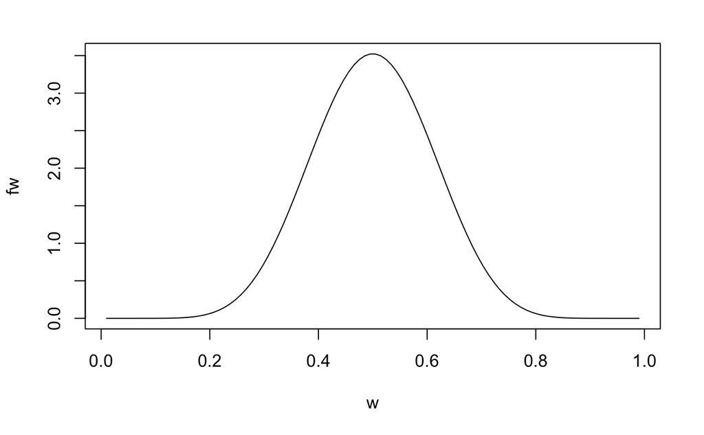

```r
#Mezcla de betas
pp=0.3
w<-seq(0.01,0.99,,100)
fw<-dbeta(w,10,10)
par(mfrow=c(1,1))
plot(w,fw,type="l")
w<-seq(0.01,0.99,,100)
fw<-dbeta(w,6,0.01)
par(mfrow=c(1,1))
```

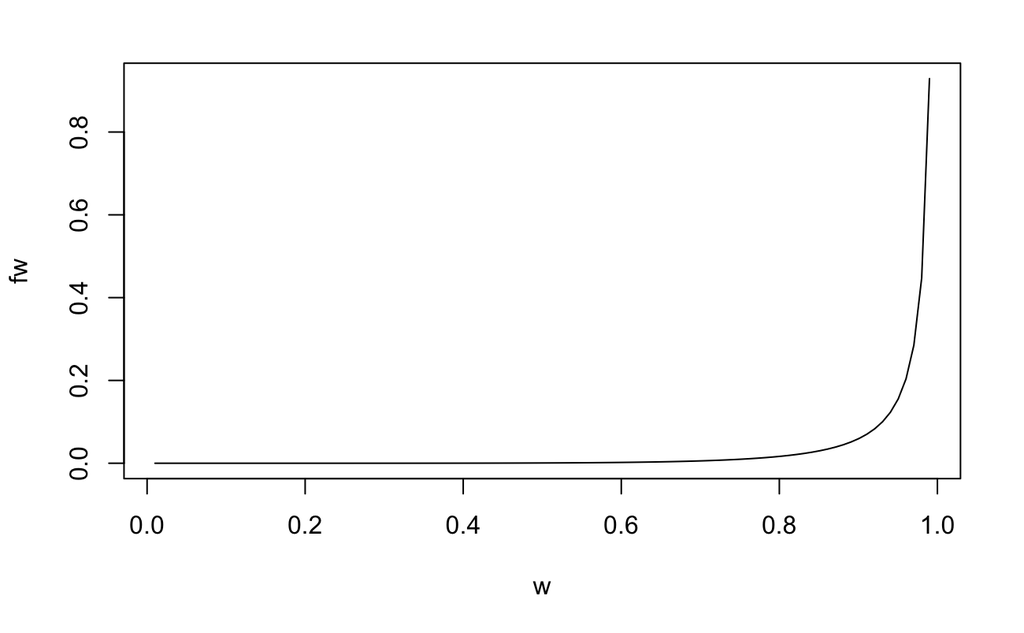

```r
plot(w,fw,type="l")
# DIST INICIAL
w<-seq(0.01,0.99,,100)
pp<-0.3
fw<-pp*dbeta(w,10,10.1)+(1-pp)*dbeta(w,5,0.05)
par(mfrow=c(1,1))
```

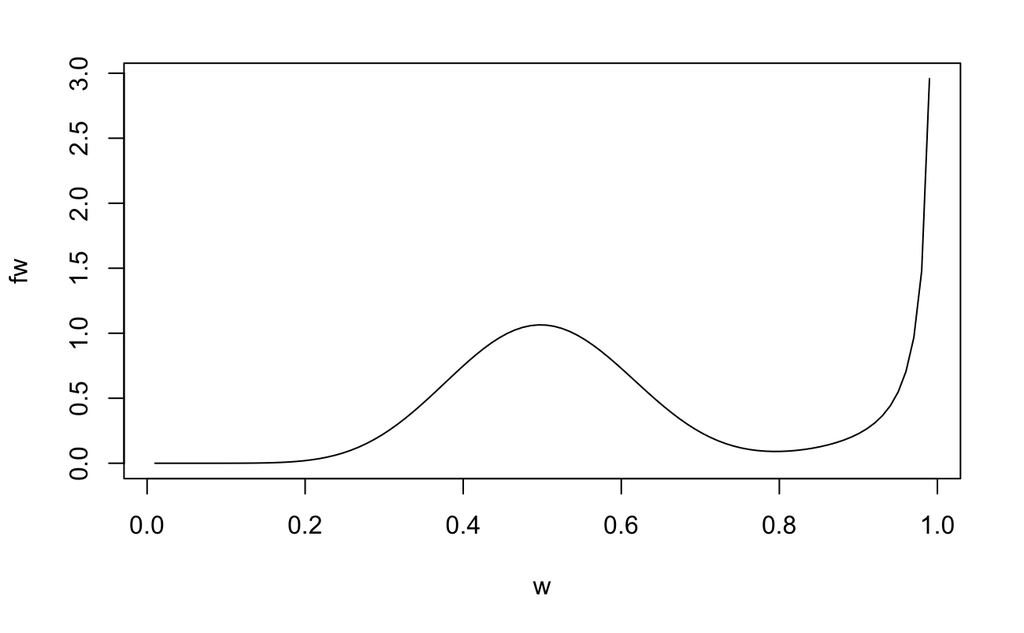

```r
plot(w,fw,type="l")
```

Este ejemplo ilustra como favorecer dos valores donde yo creo que puede estar el parámetro ($\theta$), en este caso 0.5 y 1, SIN DESCARTAR LOS DEMAS VALORES, PARA EL CASO DE QUE LOS DATOS LUEGO ME INDIQUEN QUE EL VALOR VERDADERO ES DIFERENTE DE AQUELLOS QUE YO PENSE INICIALMENTE.

```r
#--- Ejemplo 1---
#-Reading data-
# n/2 es mi theta gorro, mi estimador maximo verosimil, en este caso era la suma de las xi era 50
n<-100
credito<-c(rep(1,n/2),rep(0,n/2))
#-Defining data-
data<-list("n"=n,"x"=credito)
#-Defining inits-
# Inciializo siempre en un valor del soporte
inits<-function(){list(theta=0.5, eta=1, x1=rep(1,2))}
#-Selecting parameters to monitor-
parameters<-c("theta","eta","x1")
#-Running code-
#JAGS
ej1.sim<-jags(data,inits,parameters,model.file="Ej1_d.txt",
              n.iter=5000,n.chains=1,n.burnin=500,n.thin=1)
```

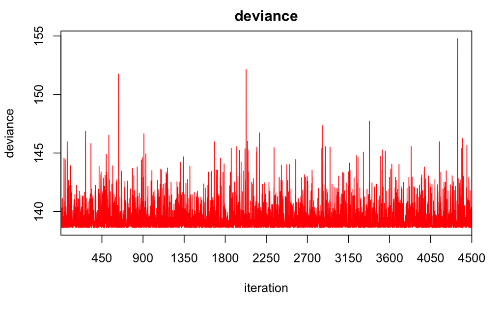

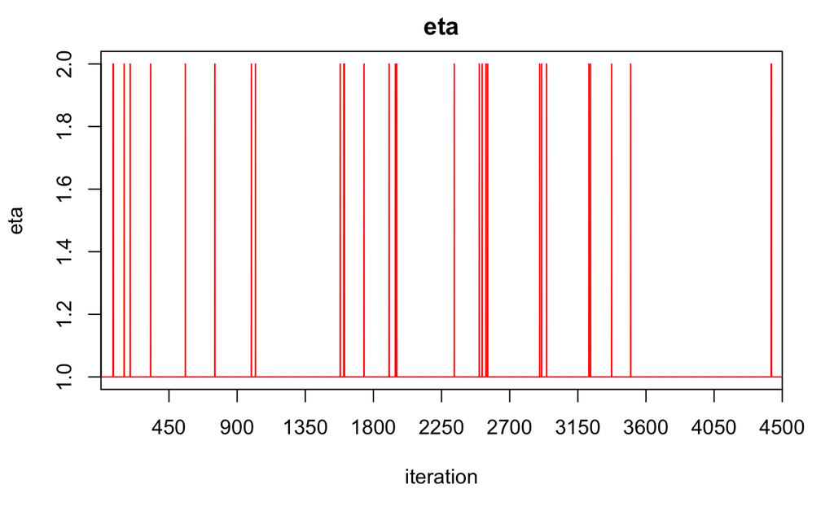

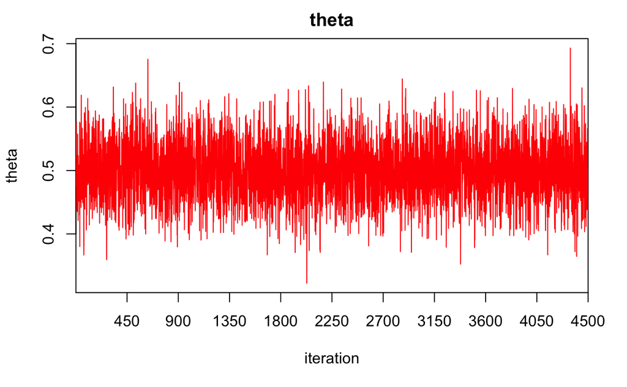

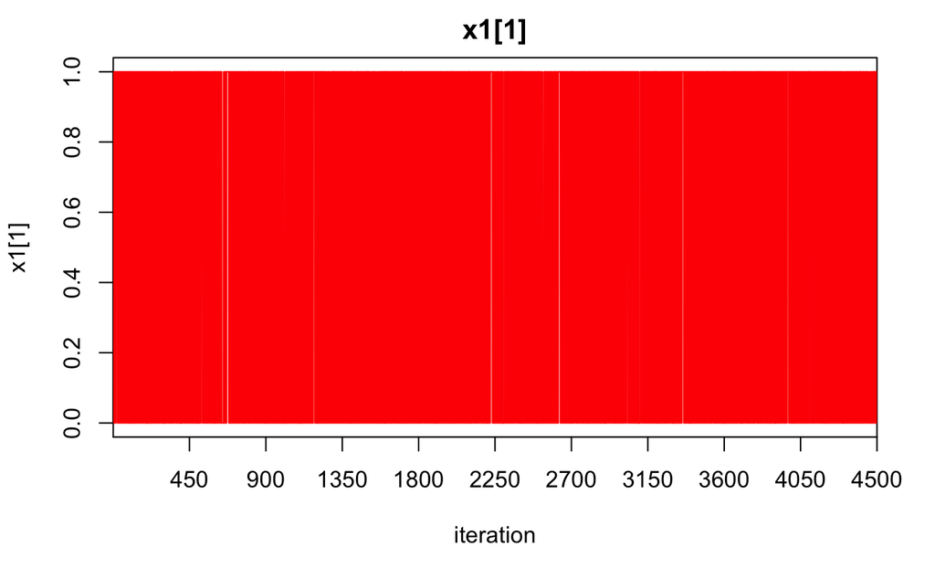

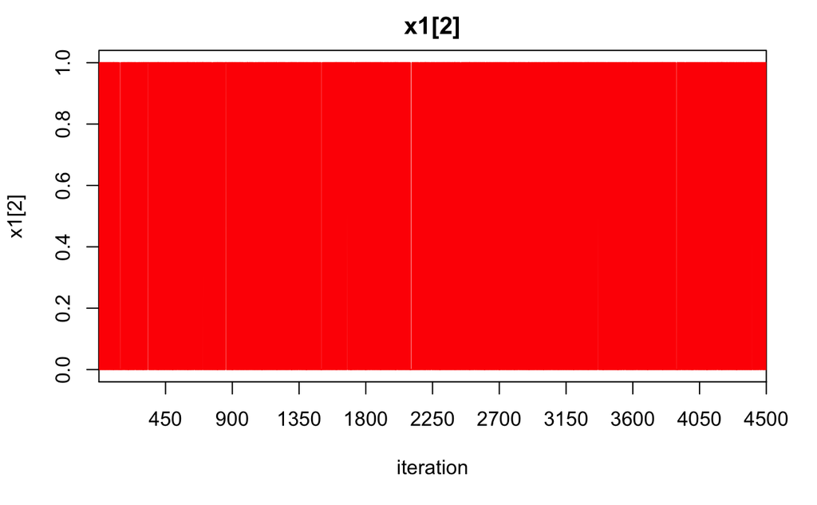

```r
#-Monitoring chain-
#Traza de la cadena
traceplot(ej1.sim)
```

Comparando esta grafica de Theta respecto del ejercicio 1.a vemos que theta se de forma similar, la razon es que una mezcla de Betas es una Distribución Conjugada con respecto a una Beta. Entonces la distribución final es otra mezcla de Betas

```r
#Cadena
#JAGS
out<-ej1.sim$BUGSoutput$sims.list
z<-out$theta
par(mfrow=c(2,2))
plot(z,type="l")
plot(cumsum(z)/(1:length(z)),type="l")
```

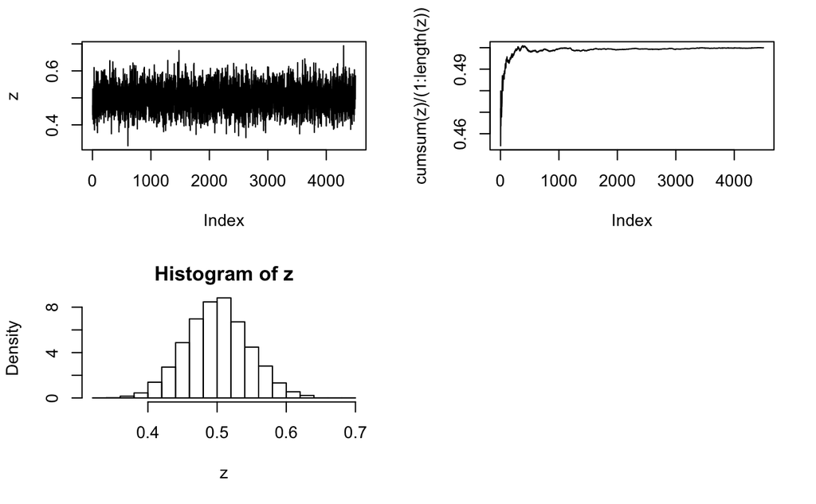

```r
hist(z,freq=FALSE)
acf(z)
```

Primer cuadro: como se está moviendo theta

Segundo: como esta convergiendo o no la media. Si se mueve mucho necesito mas iteraciones.

Tercero: Histograma de mi posterior. Mi z, es la posterior que va mezclando los componentes de ambas Betas. Pero la probabilidad inicial de cada componente es diferentes: 0.3 y 0.7; esto define una nueva Beta, con otra funcion de densidad y valores de sus parámetros. Este es el resultado de esa mezcla final. Podemos ver que sigue centradd por 0.5, pero la cola de la izq tiene mas puntos que la de la derecha, entonces esta dominada por la parte central, y la porción de la Beta que estaba sesgada a la derecha, se perdió con los datos. Esto es porque tenemos una muestra grande.

```r
#Resumen (estimadores)
#JAGS
out.sum<-ej1.sim$BUGSoutput$summary
print(out.sum)
```

```
                mean         sd        2.5%         25%         50%         75%       97.5%
deviance 139.4814599 1.22476720 138.6301974 138.7097646 139.0028463 139.7404582 142.9132724
eta        1.0068889 0.08272214   1.0000000   1.0000000   1.0000000   1.0000000   1.0000000
theta      0.4999603 0.04585975   0.4102336   0.4692565   0.4998205   0.5302978   0.5905107
x1[1]      0.4986667 0.50005379   0.0000000   0.0000000   0.0000000   1.0000000   1.0000000
x1[2]      0.4933333 0.50001111   0.0000000   0.0000000   0.0000000   1.0000000   1.0000000
```

```r
#DIC
#JAGS
out.dic<-ej1.sim$BUGSoutput$DIC
print(out.dic)
```

```
[1] 140.2315
```

ESTE RESUMEN ME DICE

Para mis datos: $x1...xn$ es una m.a. proveniente de una dist Bernoulli (exito=otorgado, fracaso=no otorgado)

Con distribuion inicial de Mezcla de Betas.

RESULTA EN:

EN ESTE CASO, AL USAR LA DIST INICIAL COMO MEZCLA DE BETAS, MIS ESTIMACIONES SON MENOS CERTERAS.

[output not shown]